# SI 618 - Machine Learning Pipelines for Regression

### Dr. Chris Teplovs, School of Information, University of Michigan

Copyright © 2024. This notebook may not be shared outside of the course without permission.

### Please ensure you have this version:

Version 2024.03.05.1.CT

## Part I

**Based on Géron Chapter 2 – End-to-end Machine Learning project**

*Welcome to Machine Learning Housing Corp.! Your task is to predict median house values in Californian districts, given a number of features from these districts.*

```python
import pandas as pd
import numpy as np
import seaborn as sns
import matplotlib.pyplot as plt
```

```python
housing = pd.read_csv('https://github.com/umsi-data-science/data/raw/main/housing.csv')
```

```python
housing.head()
```

|  | longitude | latitude | housing_median_age | total_rooms | total_bedrooms | population | households | median_income | median_house_value | ocean_proximity |
| --- | --- | --- | --- | --- | --- | --- | --- | --- | --- | --- |
| 0 | -122.23 | 37.88 | 41.0 | 880.0 | 129.0 | 322.0 | 126.0 | 8.3252 | 452600.0 | NEAR BAY |
| 1 | -122.22 | 37.86 | 21.0 | 7099.0 | 1106.0 | 2401.0 | 1138.0 | 8.3014 | 358500.0 | NEAR BAY |
| 2 | -122.24 | 37.85 | 52.0 | 1467.0 | 190.0 | 496.0 | 177.0 | 7.2574 | 352100.0 | NEAR BAY |
| 3 | -122.25 | 37.85 | 52.0 | 1274.0 | 235.0 | 558.0 | 219.0 | 5.6431 | 341300.0 | NEAR BAY |
| 4 | -122.25 | 37.85 | 52.0 | 1627.0 | 280.0 | 565.0 | 259.0 | 3.8462 | 342200.0 | NEAR BAY |

```python
housing.info()
```

```
<class 'pandas.core.frame.DataFrame'>
RangeIndex: 20640 entries, 0 to 20639
Data columns (total 10 columns):
 #   Column              Non-Null Count  Dtype
---  ------              --------------  -----
 0   longitude           20640 non-null  float64
 1   latitude            20640 non-null  float64
 2   housing_median_age  20640 non-null  float64
 3   total_rooms         20640 non-null  float64
 4   total_bedrooms      20433 non-null  float64
 5   population          20640 non-null  float64
 6   households          20640 non-null  float64
 7   median_income       20640 non-null  float64
 8   median_house_value  20640 non-null  float64
 9   ocean_proximity     20640 non-null  object
dtypes: float64(9), object(1)
memory usage: 1.6+ MB
```

```python
housing["ocean_proximity"].value_counts()
```

```
ocean_proximity
<1H OCEAN     9136
INLAND        6551
NEAR OCEAN    2658
NEAR BAY      2290
ISLAND           5
Name: count, dtype: int64
```

```python
housing.describe()
```

|  | longitude | latitude | housing_median_age | total_rooms | total_bedrooms | population | households | median_income | median_house_value |
| --- | --- | --- | --- | --- | --- | --- | --- | --- | --- |
| count | 20640.000000 | 20640.000000 | 20640.000000 | 20640.000000 | 20433.000000 | 20640.000000 | 20640.000000 | 20640.000000 | 20640.000000 |
| mean | -119.569704 | 35.631861 | 28.639486 | 2635.763081 | 537.870553 | 1425.476744 | 499.539680 | 3.870671 | 206855.816909 |
| std | 2.003532 | 2.135952 | 12.585558 | 2181.615252 | 421.385070 | 1132.462122 | 382.329753 | 1.899822 | 115395.615874 |
| min | -124.350000 | 32.540000 | 1.000000 | 2.000000 | 1.000000 | 3.000000 | 1.000000 | 0.499900 | 14999.000000 |
| 25% | -121.800000 | 33.930000 | 18.000000 | 1447.750000 | 296.000000 | 787.000000 | 280.000000 | 2.563400 | 119600.000000 |
| 50% | -118.490000 | 34.260000 | 29.000000 | 2127.000000 | 435.000000 | 1166.000000 | 409.000000 | 3.534800 | 179700.000000 |
| 75% | -118.010000 | 37.710000 | 37.000000 | 3148.000000 | 647.000000 | 1725.000000 | 605.000000 | 4.743250 | 264725.000000 |
| max | -114.310000 | 41.950000 | 52.000000 | 39320.000000 | 6445.000000 | 35682.000000 | 6082.000000 | 15.000100 | 500001.000000 |

```python
from random import randint
```

```python
# to make this notebook's output identical at every run
np.random.seed(42)
```

```python
for i in range(10):
    print(np.random.randint(0, 10))
```

```
6
3
7
4
6
9
2
6
7
4
```

```python
from sklearn.model_selection import train_test_split

train_set, test_set = train_test_split(housing, test_size=0.2, random_state=42)
```

```python
test_set.shape
```

```
(4128, 10)
```

```python
train_set.shape
```

```
(16512, 10)
```

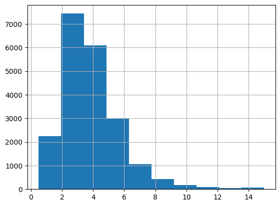

```python
housing["median_income"].hist()
```

```python
housing["income_cat"] = pd.cut(housing["median_income"],
                                bins=[0., 1.5, 3.0, 4.5, 6., np.inf],
                                labels=[1, 2, 3, 4, 5])
```

```python
housing["income_cat"].value_counts()
```

```
income_cat
3    7236
2    6581
4    3639
5    2362
1     822
Name: count, dtype: int64
```

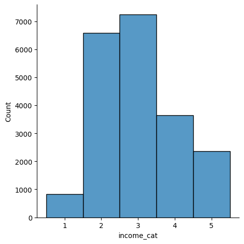

```python
sns.displot(housing["income_cat"])
```

```python
from sklearn.model_selection import StratifiedShuffleSplit

split = StratifiedShuffleSplit(n_splits=1, test_size=0.2, random_state=42)
for train_index, test_index in split.split(housing, housing["income_cat"]):
    strat_train_set = housing.loc[train_index]
    strat_test_set = housing.loc[test_index]
```

```python
strat_test_set["income_cat"].value_counts() / len(strat_test_set)
```

```
income_cat
3    0.350533
2    0.318798
4    0.176357
5    0.114341
1    0.039971
Name: count, dtype: float64
```

```python
housing["income_cat"].value_counts() / len(housing)
```

```
income_cat
3    0.350581
2    0.318847
4    0.176308
5    0.114438
1    0.039826
Name: count, dtype: float64
```

```python
def income_cat_proportions(data):
    return data["income_cat"].value_counts() / len(data)

train_set, test_set = train_test_split(housing, test_size=0.2, random_state=42)

compare_props = pd.DataFrame({
    "Overall": income_cat_proportions(housing),
    "Stratified": income_cat_proportions(strat_test_set),
    "Random": income_cat_proportions(test_set),
}).sort_index()
compare_props["Rand. %error"] = 100 * compare_props["Random"] / compare_props["Overall"] - 100
compare_props["Strat. %error"] = 100 * compare_props["Stratified"] / compare_props["Overall"] - 100
```

```python
compare_props
```

| income_cat | Overall | Stratified | Random | Rand. %error | Strat. %error |
| --- | --- | --- | --- | --- | --- |
| 1 | 0.039826 | 0.039971 | 0.040213 | 0.973236 | 0.364964 |
| 2 | 0.318847 | 0.318798 | 0.324370 | 1.732260 | -0.015195 |
| 3 | 0.350581 | 0.350533 | 0.358527 | 2.266446 | -0.013820 |
| 4 | 0.176308 | 0.176357 | 0.167393 | -5.056334 | 0.027480 |
| 5 | 0.114438 | 0.114341 | 0.109496 | -4.318374 | -0.084674 |

```python
for set_ in (strat_train_set, strat_test_set):
    set_.drop("income_cat", axis=1, inplace=True)
```

### Prepare the data for Machine Learning algorithms

```python
housing = strat_train_set.drop("median_house_value", axis=1) # drop labels for training set
housing_labels = strat_train_set["median_house_value"].copy()
```

```python
sample_incomplete_rows = housing[housing.isnull().any(axis=1)].head()
sample_incomplete_rows
```

|  | longitude | latitude | housing_median_age | total_rooms | total_bedrooms | population | households | median_income | ocean_proximity |
| --- | --- | --- | --- | --- | --- | --- | --- | --- | --- |
| 1606 | -122.08 | 37.88 | 26.0 | 2947.0 | NaN | 825.0 | 626.0 | 2.9330 | NEAR BAY |
| 10915 | -117.87 | 33.73 | 45.0 | 2264.0 | NaN | 1970.0 | 499.0 | 3.4193 | <1H OCEAN |
| 19150 | -122.70 | 38.35 | 14.0 | 2313.0 | NaN | 954.0 | 397.0 | 3.7813 | <1H OCEAN |
| 4186 | -118.23 | 34.13 | 48.0 | 1308.0 | NaN | 835.0 | 294.0 | 4.2891 | <1H OCEAN |
| 16885 | -122.40 | 37.58 | 26.0 | 3281.0 | NaN | 1145.0 | 480.0 | 6.3580 | NEAR OCEAN |

```python
sample_incomplete_rows.dropna(subset=["total_bedrooms"])    # option 1
```

|  | longitude | latitude | housing_median_age | total_rooms | total_bedrooms | population | households | median_income | ocean_proximity |
| --- | --- | --- | --- | --- | --- | --- | --- | --- | --- |

```python
sample_incomplete_rows.drop("total_bedrooms", axis=1)       # option 2
```

|  | longitude | latitude | housing_median_age | total_rooms | population | households | median_income | ocean_proximity |
| --- | --- | --- | --- | --- | --- | --- | --- | --- |
| 1606 | -122.08 | 37.88 | 26.0 | 2947.0 | 825.0 | 626.0 | 2.9330 | NEAR BAY |
| 10915 | -117.87 | 33.73 | 45.0 | 2264.0 | 1970.0 | 499.0 | 3.4193 | <1H OCEAN |
| 19150 | -122.70 | 38.35 | 14.0 | 2313.0 | 954.0 | 397.0 | 3.7813 | <1H OCEAN |
| 4186 | -118.23 | 34.13 | 48.0 | 1308.0 | 835.0 | 294.0 | 4.2891 | <1H OCEAN |
| 16885 | -122.40 | 37.58 | 26.0 | 3281.0 | 1145.0 | 480.0 | 6.3580 | NEAR OCEAN |

```python
median = housing["total_bedrooms"].median()
sample_incomplete_rows["total_bedrooms"].fillna(median, inplace=True) # option 3
```

```python
sample_incomplete_rows
```

|  | longitude | latitude | housing_median_age | total_rooms | total_bedrooms | population | households | median_income | ocean_proximity |
| --- | --- | --- | --- | --- | --- | --- | --- | --- | --- |
| 1606 | -122.08 | 37.88 | 26.0 | 2947.0 | 433.0 | 825.0 | 626.0 | 2.9330 | NEAR BAY |
| 10915 | -117.87 | 33.73 | 45.0 | 2264.0 | 433.0 | 1970.0 | 499.0 | 3.4193 | <1H OCEAN |
| 19150 | -122.70 | 38.35 | 14.0 | 2313.0 | 433.0 | 954.0 | 397.0 | 3.7813 | <1H OCEAN |
| 4186 | -118.23 | 34.13 | 48.0 | 1308.0 | 433.0 | 835.0 | 294.0 | 4.2891 | <1H OCEAN |
| 16885 | -122.40 | 37.58 | 26.0 | 3281.0 | 433.0 | 1145.0 | 480.0 | 6.3580 | NEAR OCEAN |

```python
from sklearn.impute import SimpleImputer
# fill in missing values with the median values
imputer = SimpleImputer(strategy="median")
```

Remove the text attribute because median can only be calculated on numerical attributes:

```python
housing_num = housing.drop("ocean_proximity", axis=1)
# alternatively: housing_num = housing.select_dtypes(include=[np.number])
```

```python
housing_num.head()
```

|  | longitude | latitude | housing_median_age | total_rooms | total_bedrooms | population | households | median_income |
| --- | --- | --- | --- | --- | --- | --- | --- | --- |
| 12655 | -121.46 | 38.52 | 29.0 | 3873.0 | 797.0 | 2237.0 | 706.0 | 2.1736 |
| 15502 | -117.23 | 33.09 | 7.0 | 5320.0 | 855.0 | 2015.0 | 768.0 | 6.3373 |
| 2908 | -119.04 | 35.37 | 44.0 | 1618.0 | 310.0 | 667.0 | 300.0 | 2.8750 |
| 14053 | -117.13 | 32.75 | 24.0 | 1877.0 | 519.0 | 898.0 | 483.0 | 2.2264 |
| 20496 | -118.70 | 34.28 | 27.0 | 3536.0 | 646.0 | 1837.0 | 580.0 | 4.4964 |

```python
imputer.fit(housing_num)
```

```
SimpleImputer(strategy='median')
```

```python
housing_num.head()
```

|  | longitude | latitude | housing_median_age | total_rooms | total_bedrooms | population | households | median_income |
| --- | --- | --- | --- | --- | --- | --- | --- | --- |
| 12655 | -121.46 | 38.52 | 29.0 | 3873.0 | 797.0 | 2237.0 | 706.0 | 2.1736 |
| 15502 | -117.23 | 33.09 | 7.0 | 5320.0 | 855.0 | 2015.0 | 768.0 | 6.3373 |
| 2908 | -119.04 | 35.37 | 44.0 | 1618.0 | 310.0 | 667.0 | 300.0 | 2.8750 |
| 14053 | -117.13 | 32.75 | 24.0 | 1877.0 | 519.0 | 898.0 | 483.0 | 2.2264 |
| 20496 | -118.70 | 34.28 | 27.0 | 3536.0 | 646.0 | 1837.0 | 580.0 | 4.4964 |

```python
imputer.statistics_
# show the median of the vaeribles
```

```
array([-118.51   ,   34.26   ,   29.     , 2119.     ,  433.     ,
       1164.     ,  408.     ,    3.54155])
```

Check that this is the same as manually computing the median of each attribute:

```python
housing_num.median().values
```

```
array([-118.51   ,   34.26   ,   29.     , 2119.     ,  433.     ,
       1164.     ,  408.     ,    3.54155])
```

Transform the training set:

```python
X = imputer.transform(housing_num)
```

```python
X
```

```
array([[-1.2146e+02,  3.8520e+01,  2.9000e+01, ...,  2.2370e+03,
         7.0600e+02,  2.1736e+00],
       [-1.1723e+02,  3.3090e+01,  7.0000e+00, ...,  2.0150e+03,
         7.6800e+02,  6.3373e+00],
       [-1.1904e+02,  3.5370e+01,  4.4000e+01, ...,  6.6700e+02,
         3.0000e+02,  2.8750e+00],
       ...,
       [-1.2272e+02,  3.8440e+01,  4.8000e+01, ...,  4.5800e+02,
         1.7200e+02,  3.1797e+00],
       [-1.2270e+02,  3.8310e+01,  1.4000e+01, ...,  1.2080e+03,
         5.0100e+02,  4.1964e+00],
       [-1.2214e+02,  3.9970e+01,  2.7000e+01, ...,  6.2500e+02,
         1.9700e+02,  3.1319e+00]])
```

Now let's preprocess the categorical input feature, `ocean_proximity`:

```python
housing_cat = housing[["ocean_proximity"]]
housing_cat.head(10)
```

|  | ocean_proximity |
| --- | --- |
| 12655 | INLAND |
| 15502 | NEAR OCEAN |
| 2908 | INLAND |
| 14053 | NEAR OCEAN |
| 20496 | <1H OCEAN |
| 1481 | NEAR BAY |
| 18125 | <1H OCEAN |
| 5830 | <1H OCEAN |
| 17989 | <1H OCEAN |
| 4861 | <1H OCEAN |

```python
from sklearn.preprocessing import OrdinalEncoder
# convert the categorical values to numerical values, sort in alphabetical order
ordinal_encoder = OrdinalEncoder()
housing_cat_encoded = ordinal_encoder.fit_transform(housing_cat)
housing_cat_encoded[:10]
```

```
array([[1.],
       [4.],
       [1.],
       [4.],
       [0.],
       [3.],
       [0.],
       [0.],
       [0.],
       [0.]])
```

```python
ordinal_encoder.categories_
```

```
[array(['<1H OCEAN', 'INLAND', 'ISLAND', 'NEAR BAY', 'NEAR OCEAN'],
       dtype=object)]
```

```python
from sklearn.preprocessing import OneHotEncoder

cat_encoder = OneHotEncoder()
housing_cat_1hot = cat_encoder.fit_transform(housing_cat)
housing_cat_1hot
```

```
<16512x5 sparse matrix of type '<class 'numpy.float64'>'
	with 16512 stored elements in Compressed Sparse Row format>
```

By default, the `OneHotEncoder` class returns a sparse array, but we can convert it to a dense array if needed by calling the `toarray()` method:

```python
housing_cat_1hot.toarray()
```

```
array([[0., 1., 0., 0., 0.],
       [0., 0., 0., 0., 1.],
       [0., 1., 0., 0., 0.],
       ...,
       [1., 0., 0., 0., 0.],
       [1., 0., 0., 0., 0.],
       [0., 1., 0., 0., 0.]])
```

Alternatively, you can set `sparse=False` when creating the `OneHotEncoder`:

```python
cat_encoder = OneHotEncoder(sparse_output=False)
housing_cat_1hot = cat_encoder.fit_transform(housing_cat)
housing_cat_1hot
```

```
array([[0., 1., 0., 0., 0.],
       [0., 0., 0., 0., 1.],
       [0., 1., 0., 0., 0.],
       ...,
       [1., 0., 0., 0., 0.],
       [1., 0., 0., 0., 0.],
       [0., 1., 0., 0., 0.]])
```

```python
cat_encoder.categories_
```

```
[array(['<1H OCEAN', 'INLAND', 'ISLAND', 'NEAR BAY', 'NEAR OCEAN'],
       dtype=object)]
```

Let's create a custom transformer to add extra attributes:

```python
from sklearn.base import BaseEstimator, TransformerMixin

# column index
rooms_ix, bedrooms_ix, population_ix, households_ix = 3, 4, 5, 6

class CombinedAttributesAdder(BaseEstimator, TransformerMixin):
    def __init__(self, add_bedrooms_per_room = True): # no *args or **kargs
        self.add_bedrooms_per_room = add_bedrooms_per_room
    def fit(self, X, y=None):
        return self  # nothing else to do
    def transform(self, X):
        rooms_per_household = X[:, rooms_ix] / X[:, households_ix]
        population_per_household = X[:, population_ix] / X[:, households_ix]
        if self.add_bedrooms_per_room:
            bedrooms_per_room = X[:, bedrooms_ix] / X[:, rooms_ix]
            return np.c_[X, rooms_per_household, population_per_household,
                         bedrooms_per_room]
        else:
            return np.c_[X, rooms_per_household, population_per_household]

attr_adder = CombinedAttributesAdder(add_bedrooms_per_room=False)
housing_extra_attribs = attr_adder.transform(housing.values)
```

```python
housing_extra_attribs
```

```
array([[-121.46, 38.52, 29.0, ..., 'INLAND', 5.485835694050992,
        3.168555240793201],
       [-117.23, 33.09, 7.0, ..., 'NEAR OCEAN', 6.927083333333333,
        2.6236979166666665],
       [-119.04, 35.37, 44.0, ..., 'INLAND', 5.3933333333333335,
        2.223333333333333],
       ...,
       [-122.72, 38.44, 48.0, ..., '<1H OCEAN', 4.1104651162790695,
        2.6627906976744184],
       [-122.7, 38.31, 14.0, ..., '<1H OCEAN', 6.297405189620759,
        2.411177644710579],
       [-122.14, 39.97, 27.0, ..., 'INLAND', 5.477157360406092,
        3.1725888324873095]], dtype=object)
```

```python
housing_extra_attribs = pd.DataFrame(
    housing_extra_attribs,
    columns=list(housing.columns)+["rooms_per_household", "population_per_household"],
    index=housing.index)
housing_extra_attribs.head()
```

|  | longitude | latitude | housing_median_age | total_rooms | total_bedrooms | population | households | median_income | ocean_proximity | rooms_per_household | population_per_household |
| --- | --- | --- | --- | --- | --- | --- | --- | --- | --- | --- | --- |
| 12655 | -121.46 | 38.52 | 29.0 | 3873.0 | 797.0 | 2237.0 | 706.0 | 2.1736 | INLAND | 5.485836 | 3.168555 |
| 15502 | -117.23 | 33.09 | 7.0 | 5320.0 | 855.0 | 2015.0 | 768.0 | 6.3373 | NEAR OCEAN | 6.927083 | 2.623698 |
| 2908 | -119.04 | 35.37 | 44.0 | 1618.0 | 310.0 | 667.0 | 300.0 | 2.875 | INLAND | 5.393333 | 2.223333 |
| 14053 | -117.13 | 32.75 | 24.0 | 1877.0 | 519.0 | 898.0 | 483.0 | 2.2264 | NEAR OCEAN | 3.886128 | 1.859213 |
| 20496 | -118.7 | 34.28 | 27.0 | 3536.0 | 646.0 | 1837.0 | 580.0 | 4.4964 | <1H OCEAN | 6.096552 | 3.167241 |

Now let's build a pipeline for preprocessing the numerical attributes:

```python
from sklearn.pipeline import Pipeline
from sklearn.preprocessing import StandardScaler

# define the pipeline for numeric values
num_pipeline = Pipeline([
        ('imputer', SimpleImputer(strategy="median")),
        ('attribs_adder', CombinedAttributesAdder()),
        ('std_scaler', StandardScaler()),
    ])


# fit the pipeline to the values
housing_num_tr = num_pipeline.fit_transform(housing_num)
```

```python
housing_num_tr
```

```
array([[-0.94135046,  1.34743822,  0.02756357, ...,  0.01739526,
         0.00622264, -0.12112176],
       [ 1.17178212, -1.19243966, -1.72201763, ...,  0.56925554,
        -0.04081077, -0.81086696],
       [ 0.26758118, -0.1259716 ,  1.22045984, ..., -0.01802432,
        -0.07537122, -0.33827252],
       ...,
       [-1.5707942 ,  1.31001828,  1.53856552, ..., -0.5092404 ,
        -0.03743619,  0.32286937],
       [-1.56080303,  1.2492109 , -1.1653327 , ...,  0.32814891,
        -0.05915604, -0.45702273],
       [-1.28105026,  2.02567448, -0.13148926, ...,  0.01407228,
         0.00657083, -0.12169672]])
```

```python
from sklearn.compose import ColumnTransformer

num_attribs = list(housing_num)
cat_attribs = ["ocean_proximity"]

full_pipeline = ColumnTransformer([
    # "num" for numeric columns, "cat" for categorical columns
        ("num", num_pipeline, num_attribs), # apply the pipeline to the numeric values
        ("cat", OneHotEncoder(), cat_attribs), # apply the OneHotEncoder to the categorical values
    ])

# fit the pipeline to the values
housing_prepared = full_pipeline.fit_transform(housing)
```

```python
housing_prepared
```

```
array([[-0.94135046,  1.34743822,  0.02756357, ...,  0.        ,
         0.        ,  0.        ],
       [ 1.17178212, -1.19243966, -1.72201763, ...,  0.        ,
         0.        ,  1.        ],
       [ 0.26758118, -0.1259716 ,  1.22045984, ...,  0.        ,
         0.        ,  0.        ],
       ...,
       [-1.5707942 ,  1.31001828,  1.53856552, ...,  0.        ,
         0.        ,  0.        ],
       [-1.56080303,  1.2492109 , -1.1653327 , ...,  0.        ,
         0.        ,  0.        ],
       [-1.28105026,  2.02567448, -0.13148926, ...,  0.        ,
         0.        ,  0.        ]])
```

```python
housing_prepared.shape
```

```
(16512, 16)
```

### Select and train a model

```python
from sklearn.linear_model import LinearRegression

lin_reg = LinearRegression()
lin_reg.fit(housing_prepared, housing_labels)
```

```
LinearRegression()
```

```python
# let's try the full preprocessing pipeline on a few training instances
some_data = housing.iloc[:5]
some_labels = housing_labels.iloc[:5]
some_data_prepared = full_pipeline.transform(some_data)

print("Predictions:", lin_reg.predict(some_data_prepared))
```

```
Predictions: [ 86208. 304704. 153536. 185728. 244416.]
```

Compare against the actual values:

```python
print("Labels:", list(some_labels))
```

```
Labels: [72100.0, 279600.0, 82700.0, 112500.0, 238300.0]
```

```python
some_data_prepared
```

```
array([[-0.94135046,  1.34743822,  0.02756357,  0.58477745,  0.64037127,
         0.73260236,  0.55628602, -0.8936472 ,  0.01739526,  0.00622264,
        -0.12112176,  0.        ,  1.        ,  0.        ,  0.        ,
         0.        ],
       [ 1.17178212, -1.19243966, -1.72201763,  1.26146668,  0.78156132,
         0.53361152,  0.72131799,  1.292168  ,  0.56925554, -0.04081077,
        -0.81086696,  0.        ,  0.        ,  0.        ,  0.        ,
         1.        ],
       [ 0.26758118, -0.1259716 ,  1.22045984, -0.46977281, -0.54513828,
        -0.67467519, -0.52440722, -0.52543365, -0.01802432, -0.07537122,
        -0.33827252,  0.        ,  1.        ,  0.        ,  0.        ,
         0.        ],
       [ 1.22173797, -1.35147437, -0.37006852, -0.34865152, -0.03636724,
        -0.46761716, -0.03729672, -0.86592882, -0.59513997, -0.10680295,
         0.96120521,  0.        ,  0.        ,  0.        ,  0.        ,
         1.        ],
       [ 0.43743108, -0.63581817, -0.13148926,  0.42717947,  0.27279028,
         0.37406031,  0.22089846,  0.32575178,  0.2512412 ,  0.00610923,
        -0.47451338,  1.        ,  0.        ,  0.        ,  0.        ,
         0.        ]])
```

```python
from sklearn.metrics import mean_squared_error

housing_predictions = lin_reg.predict(housing_prepared)
lin_mse = mean_squared_error(housing_labels, housing_predictions)
lin_rmse = np.sqrt(lin_mse)
lin_rmse
```

```
np.float64(68633.40810776998)
```

```python
from sklearn.metrics import mean_absolute_error

lin_mae = mean_absolute_error(housing_labels, housing_predictions)
lin_mae
```

```
np.float64(49448.131359011626)
```

### Fine-tune your model

```python
def display_scores(scores):
    print("Scores:", scores)
    print("Mean:", scores.mean())
    print("Standard deviation:", scores.std())
```

```python
from sklearn.model_selection import cross_val_score

lin_scores = cross_val_score(lin_reg, housing_prepared, housing_labels,
                             scoring="neg_mean_squared_error", cv=10)
lin_rmse_scores = np.sqrt(-lin_scores)
display_scores(lin_rmse_scores)
```

```
Scores: [71800.38078269 64114.99166359 67844.95431254 68635.19072082
 66801.98038821 72531.04505346 73991.67315777 68824.54092094
 66474.60750419 70145.6152709 ]
Mean: 69116.49797751283
Standard deviation: 2880.523135303692
```

### Apply model to test data

```python
from sklearn.metrics import root_mean_squared_error

X_test = strat_test_set.drop("median_house_value", axis=1)
y_test = strat_test_set["median_house_value"].copy()

X_test_prepared = full_pipeline.transform(X_test)

final_predictions = lin_reg.predict(X_test_prepared)

final_mse = mean_squared_error(y_test, final_predictions)
final_rmse = root_mean_squared_error(y_test, final_predictions)
```

```python
final_rmse
```

```
np.float64(66924.9521680714)
```

```python
lin_reg.coef_
```

```
array([-5.82904538e+04, -5.93594552e+04,  1.38143240e+04, -2.22734293e+03,
        7.36919844e+03, -4.59921582e+04,  4.60211213e+04,  7.48451300e+04,
        6.65572145e+03,  1.08176939e+03,  9.28169884e+03,  4.48116136e+17,
        4.48116136e+17,  4.48116136e+17,  4.48116136e+17,  4.48116136e+17])
```

```python
housing_extra_attribs.columns
```

```
Index(['longitude', 'latitude', 'housing_median_age', 'total_rooms',
       'total_bedrooms', 'population', 'households', 'median_income',
       'ocean_proximity', 'rooms_per_household', 'population_per_household'],
      dtype='object')
```

## Part II

```python
import statsmodels.formula.api as smf
```

Seaborn (and other packages) come bundled with datasets. Let's load the infamous Fisher's Iris Dataset:

```python
iris = sns.load_dataset('iris')
```

```python
iris.head()
```

|  | sepal_length | sepal_width | petal_length | petal_width | species |
| --- | --- | --- | --- | --- | --- |
| 0 | 5.1 | 3.5 | 1.4 | 0.2 | setosa |
| 1 | 4.9 | 3.0 | 1.4 | 0.2 | setosa |
| 2 | 4.7 | 3.2 | 1.3 | 0.2 | setosa |
| 3 | 4.6 | 3.1 | 1.5 | 0.2 | setosa |
| 4 | 5.0 | 3.6 | 1.4 | 0.2 | setosa |

### Challenge 1: scatterplot

Create a 2-d scatterplot of petal_width (on the y-axis) vs. petal_length (on the x-axis) that includes a regression line. You might want to use the `lmplot` function in the `seaborn` package.

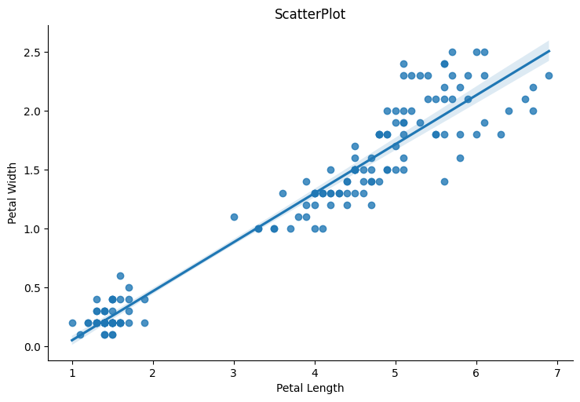

```python
# Create a scatterplot of petal_length vs. petal_width and includes a regression line
plt.figure(figsize=(10, 6))
sns.lmplot(x='petal_length', y='petal_width', data=iris, aspect=1.5)
plt.xlabel('Petal Length')
plt.ylabel('Petal Width')
plt.title('ScatterPlot')
plt.show()
```

### Challenge 2: regression

Create a regression model of petal_width as the outcome variable and petal_length as the explanatory variable. You might find the notebook on correlation and regression to be helpful here.

```python
# Create a regression model
model = smf.ols(formula='petal_width ~ petal_length', data=iris)
model_fit = model.fit()
print(model_fit.summary())
```

```
                            OLS Regression Results
==============================================================================
Dep. Variable:            petal_width   R-squared:                       0.927
Model:                            OLS   Adj. R-squared:                  0.927
Method:                 Least Squares   F-statistic:                     1882.
Date:                Thu, 17 Oct 2024   Prob (F-statistic):           4.68e-86
Time:                        15:28:59   Log-Likelihood:                 24.796
No. Observations:                 150   AIC:                            -45.59
Df Residuals:                     148   BIC:                            -39.57
Df Model:                           1
Covariance Type:            nonrobust
================================================================================
                   coef    std err          t      P>|t|      [0.025      0.975]
--------------------------------------------------------------------------------
Intercept       -0.3631      0.040     -9.131      0.000      -0.442      -0.285
petal_length     0.4158      0.010     43.387      0.000       0.397       0.435
==============================================================================
Omnibus:                        5.765   Durbin-Watson:                   1.455
Prob(Omnibus):                  0.056   Jarque-Bera (JB):                5.555
Skew:                           0.359   Prob(JB):                       0.0622
Kurtosis:                       3.611   Cond. No.                         10.3
==============================================================================

Notes:
[1] Standard Errors assume that the covariance matrix of the errors is correctly specified.
```

### Introduction to scikit-learn

Recall the general process for using a scikit-learn estimator:

1. choose appropriate class that implements what you want to do and import it
2. choose model hyperparameters (or accept default ones, but be careful) and instantiate class
3. arrange data into features and labels
4. .fit() your model to the data
5. apply model to new data with .predict() for supervised learning

Let's do that with the regression model we implemented using statsmodels above:

1. choose appropriate class that implements what you want to do and import it

This takes a bit of experience to figure out, but we'll cover the common ones over the next few classes. For now, I'll tell you that we want to use sklearn.linear_model.LinearRegression. Import only that class into your default namespace:

### Challenge 3: write the correct line to import LinearRegression from the sklearn.linear_model module:

```python
# import linear regression model from scikit-learn
from sklearn.linear_model import LinearRegression
```

### Challenge 4: choose model hyperparameters (or accept default ones, but be careful) and instantiate class

It's ok to accept the defaults this time. Let's assign the model to a variable called `lm`.

```python
# choose model hyperparameters and instantiate model
lm = LinearRegression()
```

### Challenge 5: arrange data into features and labels

Create one dataframe for the 'y' values (and call it 'y') and another dataframe for the 'x' values (and call it 'X').

```python
X = iris[['petal_length']]
y = iris['petal_width']
```

### Challenge 6: .fit() your model to the data

```python
lm.fit(X, y) # no need for lm = lm.fit(X, y) because the model is stored in lm
```

```
LinearRegression()
```

### Challenge 7: apply model to new data with .predict()

What's the estimated value for petal_width if the petal_length is 10?

```python
# estimate when petal_length is 10
lm.predict([[10]])
```

```
array([3.79447864])
```

```python
lm.predict([[2]])
```

```
array([0.46843531])
```

Great! But what does our model actually look like?

In the case of LinearRegression, we can access the coefficients for the equation:

```python
lm.coef_
```

```
array([0.41575542])
```

and the value of the intercept:

```python
lm.intercept_
```

```
np.float64(-0.3630755213190304)
```

Which, if we've done everything right, should match the results we got from statsmodels!

### Cross-validation

```python
from sklearn.model_selection import cross_validate
```

```python
result = cross_validate(lm, X, y, scoring='neg_mean_squared_error') # see docstring for more details
```

```python
np.mean(np.sqrt(-result['test_score']))
```

```
np.float64(0.19519549538248046)
```

https://scikit-learn.org/stable/modules/generated/sklearn.metrics.r2_score.html

Note: unlike most other scores, R^2 score may be negative (it need not actually be the square of a quantity R).

See also https://stats.stackexchange.com/questions/12900/when-is-r-squared-negative

What other scorers are available?

```python
result = cross_validate(lm, X, y, scoring='r2') # see docstring for more details
result
```

```
{'fit_time': array([0.0016911 , 0.0181241 , 0.0010519 , 0.00124002, 0.00234318]),
 'score_time': array([0.03013301, 0.00084186, 0.00091386, 0.00188589, 0.00174069]),
 'test_score': array([-0.11487018,  0.95263007,  0.38011675,  0.68756687, -0.45925651])}
```

## Part III - On your own (or in pairs)

```python
# to make this notebook's output identical at every run
np.random.seed(42)
```

```python
penguins = sns.load_dataset('penguins')
```

```python
penguins.head()
```

|  | species | island | bill_length_mm | bill_depth_mm | flipper_length_mm | body_mass_g | sex |
| --- | --- | --- | --- | --- | --- | --- | --- |
| 0 | Adelie | Torgersen | 39.1 | 18.7 | 181.0 | 3750.0 | Male |
| 1 | Adelie | Torgersen | 39.5 | 17.4 | 186.0 | 3800.0 | Female |
| 2 | Adelie | Torgersen | 40.3 | 18.0 | 195.0 | 3250.0 | Female |
| 3 | Adelie | Torgersen | NaN | NaN | NaN | NaN | NaN |
| 4 | Adelie | Torgersen | 36.7 | 19.3 | 193.0 | 3450.0 | Female |

```python
penguins.info()
```

```
<class 'pandas.core.frame.DataFrame'>
RangeIndex: 344 entries, 0 to 343
Data columns (total 7 columns):
 #   Column             Non-Null Count  Dtype
---  ------             --------------  -----
 0   species            344 non-null    object
 1   island             344 non-null    object
 2   bill_length_mm     342 non-null    float64
 3   bill_depth_mm      342 non-null    float64
 4   flipper_length_mm  342 non-null    float64
 5   body_mass_g        342 non-null    float64
 6   sex                333 non-null    object
dtypes: float64(4), object(3)
memory usage: 18.9+ KB
```

```python
penguins.dropna(inplace=True)
```

```python
penguins.info()
```

```
<class 'pandas.core.frame.DataFrame'>
Index: 333 entries, 0 to 343
Data columns (total 7 columns):
 #   Column             Non-Null Count  Dtype
---  ------             --------------  -----
 0   species            333 non-null    object
 1   island             333 non-null    object
 2   bill_length_mm     333 non-null    float64
 3   bill_depth_mm      333 non-null    float64
 4   flipper_length_mm  333 non-null    float64
 5   body_mass_g        333 non-null    float64
 6   sex                333 non-null    object
dtypes: float64(4), object(3)
memory usage: 20.8+ KB
```

### Challenge 8: Missing values

Are there any missing values? Deal with the missing values.

```python
# Find out the missing values
penguins.describe()
```

|  | bill_length_mm | bill_depth_mm | flipper_length_mm | body_mass_g |
| --- | --- | --- | --- | --- |
| count | 333.000000 | 333.000000 | 333.000000 | 333.000000 |
| mean | 43.992793 | 17.164865 | 200.966967 | 4207.057057 |
| std | 5.468668 | 1.969235 | 14.015765 | 805.215802 |
| min | 32.100000 | 13.100000 | 172.000000 | 2700.000000 |
| 25% | 39.500000 | 15.600000 | 190.000000 | 3550.000000 |
| 50% | 44.500000 | 17.300000 | 197.000000 | 4050.000000 |
| 75% | 48.600000 | 18.700000 | 213.000000 | 4775.000000 |
| max | 59.600000 | 21.500000 | 231.000000 | 6300.000000 |

```python
penguins.info()
```

```
<class 'pandas.core.frame.DataFrame'>
Index: 333 entries, 0 to 343
Data columns (total 7 columns):
 #   Column             Non-Null Count  Dtype
---  ------             --------------  -----
 0   species            333 non-null    object
 1   island             333 non-null    object
 2   bill_length_mm     333 non-null    float64
 3   bill_depth_mm      333 non-null    float64
 4   flipper_length_mm  333 non-null    float64
 5   body_mass_g        333 non-null    float64
 6   sex                333 non-null    object
dtypes: float64(4), object(3)
memory usage: 20.8+ KB
```

There are no missing values in the penguins dataset as we drop them in `dropna()`

### Challenge 9: value_counts()

Use .value_counts() to get a sense of the distribution of categorical variables.

```python
penguins.species.value_counts()
```

```
species
Adelie       146
Gentoo       119
Chinstrap     68
Name: count, dtype: int64
```

```python
penguins.island.value_counts()
```

```
island
Biscoe       163
Dream        123
Torgersen     47
Name: count, dtype: int64
```

```python
penguins.sex.value_counts()
```

```
sex
Male      168
Female    165
Name: count, dtype: int64
```

### Challenge 10: scatterplots

Create scatterplots for all combinations of numeric variables. (Hint: sns.pairplot() might be useful, and if you color by species you'll see some pretty interesting things.)

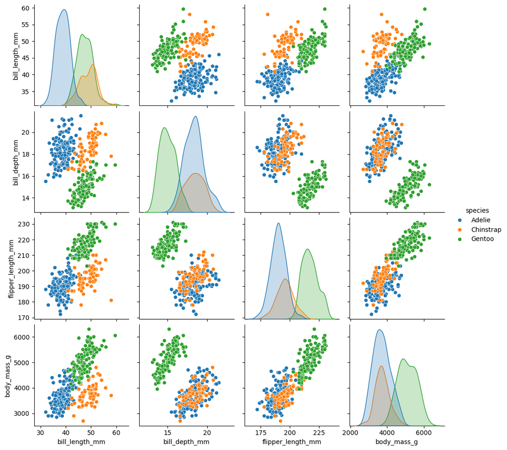

```python
# Create scatterplots for all combinations of numeric columns, with pairplot(), colored by species
plt.figure(figsize=(10, 6))
sns.pairplot(penguins, hue='species')
plt.show()
```

The body characteristics for penguins from three species are pretty different in terms of their distributions.

### Challenge 11: train-test split

Split the data into training and testing sets, ensuring that the same distribution of species exists in the split data sets as the distribution of species in the original dataframe.

```python
# split the data into training and testing with stratified split
split = StratifiedShuffleSplit(n_splits=1, test_size=0.2, random_state=42)
for train_index, test_index in split.split(penguins, penguins["species"]):
    strat_train_set = penguins.iloc[train_index]
    strat_test_set = penguins.iloc[test_index]
```

```python
strat_train_set.info()
```

```
<class 'pandas.core.frame.DataFrame'>
Index: 266 entries, 268 to 70
Data columns (total 7 columns):
 #   Column             Non-Null Count  Dtype
---  ------             --------------  -----
 0   species            266 non-null    object
 1   island             266 non-null    object
 2   bill_length_mm     266 non-null    float64
 3   bill_depth_mm      266 non-null    float64
 4   flipper_length_mm  266 non-null    float64
 5   body_mass_g        266 non-null    float64
 6   sex                266 non-null    object
dtypes: float64(4), object(3)
memory usage: 16.6+ KB
```

```python
strat_train_set['species'].value_counts()/len(strat_train_set)
```

```
species
Adelie       0.439850
Gentoo       0.357143
Chinstrap    0.203008
Name: count, dtype: float64
```

```python
strat_test_set['species'].value_counts()/len(strat_test_set)
```

```
species
Adelie       0.432836
Gentoo       0.358209
Chinstrap    0.208955
Name: count, dtype: float64
```

### Challenge 12: Create a design matrix and a label matrix

Create a design matrix (`penguins_X`) and a label matrix (`penguins_y`) from the stratified training set.

```python
# create the characteristics matrix and label matrix
penguins_X = strat_train_set.drop('species', axis=1)
penguins_y = strat_train_set['species']
```

### Challenge 13: Create a pipeline

Create a pipeline to apply a `StandardScaler()` to all numeric values and a `OneHotEncoder()` to the categorical variables in `penguins_X`. Assign the resulting matrix to a variable called `penguins_prepared`.

```python
# Create the pipeline for numeric values and categorical values
num_pipeline = Pipeline([
    ('std_scaler', StandardScaler())
])

transformer_pipeline = ColumnTransformer([
    ('num', num_pipeline, ['bill_length_mm', 'bill_depth_mm', 'flipper_length_mm', 'body_mass_g']),
    ('cat', OneHotEncoder(), ['island', 'sex'])  # Instantiate OneHotEncoder
])

# transformer_pipeline = ColumnTransformer([
#   ('num', StandardScaler(), penguins_X.select_dtypes(include=[np.number]).columns),
#   ('cat', OneHotEncoder(), penguins_X.select_dtypes(exclude=[np.number]]).columns)])



# Fit the pipeline to the values and assign the matrix to penguins_prepared
penguins_prepared = transformer_pipeline.fit_transform(penguins_X)
```

```python
penguins_prepared
```

```
array([[ 0.16732502, -1.99231135,  0.83478089, ...,  0.        ,
         1.        ,  0.        ],
       [ 1.22705014,  1.25552054,  0.1212471 , ...,  0.        ,
         0.        ,  1.        ],
       [ 0.87989881, -0.52063753,  1.4769613 , ...,  0.        ,
         0.        ,  1.        ],
       ...,
       [ 0.02115604,  1.25552054, -0.37822656, ...,  0.        ,
         0.        ,  1.        ],
       [ 0.80681432, -0.46989015,  1.33425454, ...,  0.        ,
         0.        ,  1.        ],
       [-1.91558298,  0.90028893, -0.80634683, ...,  1.        ,
         1.        ,  0.        ]])
```

### Challenge 14: Fit a linear regression

Fit a linear regression to penguins_prepared and penguins_y.

```python
# One hot encoding the penguins_y
ordinal_encoder = OrdinalEncoder()
penguins_y_encoded = ordinal_encoder.fit_transform(penguins_y.to_frame())
```

```python
# fit the linear regression
lm.fit(penguins_prepared, penguins_y_encoded)
```

```
LinearRegression()
```

### Challenge 15: Predictions

Use the fitted model to show the predicted values for the first 5 rows of data.

```python
# show the predicted values for the first 5 rows
lm.predict(penguins_prepared[:5])
```

```
array([[ 2.08840262],
       [ 0.87339186],
       [ 1.9686293 ],
       [ 0.24110306],
       [-0.18840096]])
```

### Challenge 16: Evaluate the model

Show the mean and standard deviation of the root mean squared error for your model.

```python
# show the mean and sd of RMSE
result = cross_validate(lm, penguins_prepared, penguins_y_encoded, scoring='neg_mean_squared_error', cv=10)
rmse = np.mean(np.sqrt(-result['test_score']))
rmse_mean = np.mean(rmse)
rmse_sd = np.std(rmse)
print(f"The mean of RMSE is {rmse_mean:.3f} and the standard deviation of RMSE is {rmse_sd:.3f}")
```

```
The mean of RMSE is 0.251 and the standard deviation of RMSE is 0.000
```

### Challenge 17: Apply your model to the test data

Apply your model to the test data (from your train-test split) and report the final root mean squared error (RMSE).

```python
# Apply the model to the test set
penguin_X_test = strat_test_set.drop('species', axis=1)
penguin_y_test = strat_test_set['species']

penguin_X_test_prepared = transformer_pipeline.transform(penguin_X_test)
penguin_y_test_encoded = ordinal_encoder.transform(penguin_y_test.to_frame())

test_result = cross_validate(lm,
                             penguin_X_test_prepared,
                             penguin_y_test_encoded,
                             scoring='neg_mean_squared_error', cv=10)
rmse = np.mean(np.sqrt(-test_result['test_score']))
rmse_mean = np.mean(rmse)
rmse_sd = np.std(rmse)

print(f'The mean of RMSE is {rmse_mean:.3f} and the standard deviation of RMSE is {rmse_sd:.3f}')
```

```
The mean of RMSE is 0.238 and the standard deviation of RMSE is 0.000
```

### Remember to submit your notebook in .html and .ipynb format via Canvas.